# Exploratory Data Analysis

# Data Import

We will be using the cleaned data that resulted from the processing we did in `D474_DataClean.rmd`

```r
library(here)
clickstream <- read.csv(here("Data", "EditedData", "clickstream_dc.csv"))

head(clickstream)
```

```
##   key       date order country sid main_category clothing_model color location
## 1 1,1 2008-04-01     1      29   1             1            A13     1        5
## 2 1,2 2008-04-01     2      29   1             1            A16     1        6
## 3 1,3 2008-04-01     3      29   1             2             B4    10        2
## 4 1,4 2008-04-01     4      29   1             2            B17     6        6
## 5 1,5 2008-04-01     5      29   1             2             B8     4        3
## 6 1,6 2008-04-01     6      29   1             3            C56     6        1
##   model_photography price price_2 page hi_clicks
## 1                 1    28       2    1         0
## 2                 1    33       2    1         0
## 3                 1    52       1    1         0
## 4                 2    38       2    1         0
## 5                 2    52       1    1         0
## 6                 2    57       1    4         0
```

```r
str(clickstream)
```

```
## 'data.frame':    165474 obs. of  14 variables:
##  $ key              : chr  "1,1" "1,2" "1,3" "1,4" ...
##  $ date             : chr  "2008-04-01" "2008-04-01" "2008-04-01" "2008-04-01" ...
##  $ order            : int  1 2 3 4 5 6 7 8 9 1 ...
##  $ country          : int  29 29 29 29 29 29 29 29 29 29 ...
##  $ sid              : int  1 1 1 1 1 1 1 1 1 2 ...
##  $ main_category    : int  1 1 2 2 2 3 3 4 4 2 ...
##  $ clothing_model   : chr  "A13" "A16" "B4" "B17" ...
##  $ color            : int  1 1 10 6 4 6 5 9 6 9 ...
##  $ location         : int  5 6 2 6 3 1 1 5 4 5 ...
##  $ model_photography: int  1 1 1 2 2 2 2 1 2 1 ...
##  $ price            : int  28 33 52 38 52 57 33 38 48 57 ...
##  $ price_2          : int  2 2 1 2 1 1 2 1 1 1 ...
##  $ page             : int  1 1 1 1 1 4 4 4 5 2 ...
##  $ hi_clicks        : int  0 0 0 0 0 0 0 0 0 0 ...
```

Note that data has been interpreted back into a character and integer data types. We will need to convert back to date if we wish to reference it as such. (We will need this later in the document).

```r
clickstream$date <- as.Date(clickstream$date)

# Same with factors, this time keep sid as 'int' type
cols <- c("hi_clicks", "color", "model_photography", "location", "price_2", "country", "main_category", "clothing_model", "page")

clickstream[cols] <- lapply(clickstream[cols], as.factor)

str(clickstream)
```

```
## 'data.frame':    165474 obs. of  14 variables:
##  $ key              : chr  "1,1" "1,2" "1,3" "1,4" ...
##  $ date             : Date, format: "2008-04-01" "2008-04-01" ...
##  $ order            : int  1 2 3 4 5 6 7 8 9 1 ...
##  $ country          : Factor w/ 47 levels "1","2","3","4",..: 29 29 29 29 29 29 29 29 29 29 ...
##  $ sid              : int  1 1 1 1 1 1 1 1 1 2 ...
##  $ main_category    : Factor w/ 4 levels "1","2","3","4": 1 1 2 2 2 3 3 4 4 2 ...
##  $ clothing_model   : Factor w/ 217 levels "A1","A10","A11",..: 5 8 71 52 75 128 129 199 216 67 ...
##  $ color            : Factor w/ 14 levels "1","2","3","4",..: 1 1 10 6 4 6 5 9 6 9 ...
##  $ location         : Factor w/ 6 levels "1","2","3","4",..: 5 6 2 6 3 1 1 5 4 5 ...
##  $ model_photography: Factor w/ 2 levels "1","2": 1 1 1 2 2 2 2 1 2 1 ...
##  $ price            : int  28 33 52 38 52 57 33 38 48 57 ...
##  $ price_2          : Factor w/ 2 levels "1","2": 2 2 1 2 1 1 2 1 1 1 ...
##  $ page             : Factor w/ 5 levels "1","2","3","4",..: 1 1 1 1 1 4 4 4 5 2 ...
##  $ hi_clicks        : Factor w/ 2 levels "0","1": 1 1 1 1 1 1 1 1 1 1 ...
```

# Univariate Analysis

```r
library(dplyr)
library(purrr)
```

```r
# Lets take a look at our categorical variables first
categorical_cols <- clickstream %>% select(where(is.factor) | where(is.character)) %>%
  names() %>%
  setdiff("key")

# Frequency tables
categorical_cols %>%
  set_names() %>%
  map(~ clickstream %>%
        count(.data[[.x]], sort = TRUE) %>%
        mutate(pct = round(n / sum(n) * 100, 1)) %>%
        rename(level = 1))
```

```
## $country
##    level      n  pct
## 1     29 133963 81.0
## 2      9  18003 10.9
## 3     24   4091  2.5
## 4     46   2522  1.5
## 5     44   1385  0.8
## 6     16    834  0.5
## 7     21    811  0.5
## 8     34    716  0.4
## 9     41    684  0.4
## 10     3    256  0.2
## 11    27    227  0.1
## 12    12    210  0.1
## 13    42    170  0.1
```

[output cut: 310 more lines]

Some interesting insights from this table:

(Table 1) The majority (81%) of users appear to be from country 29, which according to our documentation is Poland, followed by the Czech Republic (10.9%). It is appropriate to say that the majority of our data comes from the Central European region.

(Table 4) Black and blue items are the most popular among viewers of this website

(Table 5) People appear to focus on the photos located on the top of the page and there 3.4% drop in clicks between the top middle and bottom middle (3rd most popular) picture locations.

(Table 6) En face model photography photos tended to get more clicks

(Table 7) There is not much difference in clicks between products whose price was greater than the average price of the entire category, and products whose prices were not greater.

(Table 8) The majority of users stayed on either page 1 or 2, and did not venture out to pages 3, 4 or 5.

(Table 9) The majority of clicks (68.3%) are classified as “low-engagement” clicks, or below the mean value for the entire data set.

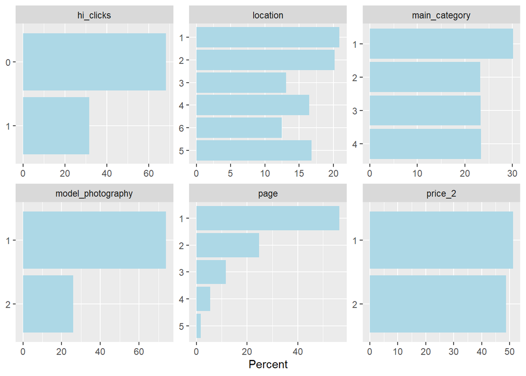

```r
library(ggplot2)
library(tidyr)
clickstream %>%
  select(where(is.factor) | where(is.character)) %>%
  select(-c(key, clothing_model, color, country)) %>%
  pivot_longer(everything(), names_to = "variable", values_to = "level") %>%
  count(variable, level) %>%
  group_by(variable) %>%
  mutate(pct = round(n / sum(n) * 100, 1)) %>%
  ggplot(aes(x = reorder(level, n), y = pct)) +
  geom_col(fill = "lightblue") +
  coord_flip() +
  facet_wrap(~ variable, scales = "free") + labs(x = NULL, y = "Percent")
```

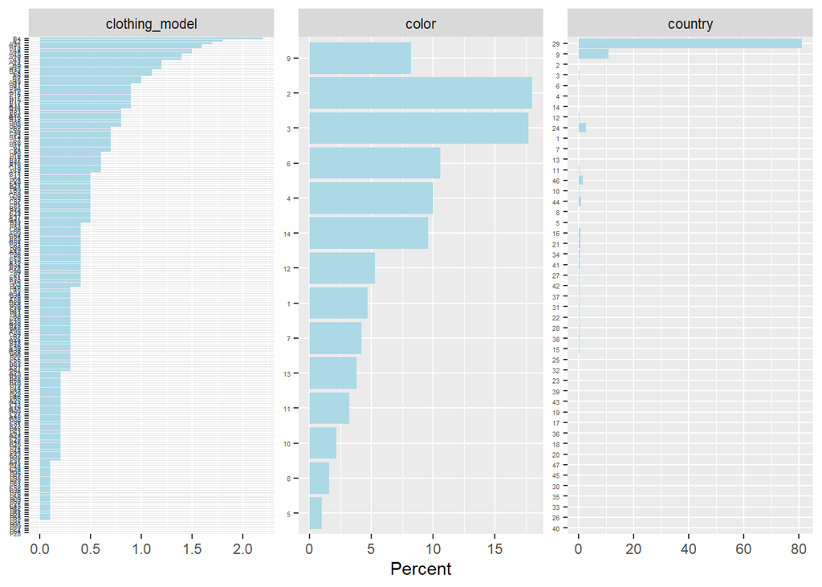

```r
clickstream %>%
  select(c(clothing_model, color, country)) %>%
  pivot_longer(everything(), names_to = "variable", values_to = "level") %>%
  count(variable, level) %>%
  group_by(variable) %>%
  mutate(pct = round(n / sum(n) * 100, 1)) %>%
  ggplot(aes(x = reorder(level, n), y = pct)) +
  geom_col(fill = "lightblue") +
  coord_flip() +
  facet_wrap(~ variable, scales = "free") +
  labs(x = NULL, y = "Percent") +
  theme(axis.text.y = element_text(size = 4))
```

Now, lets take a look at our quantitative features

```r
# Summary
clickstream %>%
  select(where(is.numeric)) %>%
  summary()
```

```
##      order              sid            price
##  Min.   :  1.000   Min.   :    1   Min.   :18.0
##  1st Qu.:  2.000   1st Qu.: 5931   1st Qu.:33.0
##  Median :  6.000   Median :11968   Median :43.0
##  Mean   :  9.817   Mean   :12058   Mean   :43.8
##  3rd Qu.: 12.000   3rd Qu.:18219   3rd Qu.:52.0
##  Max.   :195.000   Max.   :24026   Max.   :82.0
```

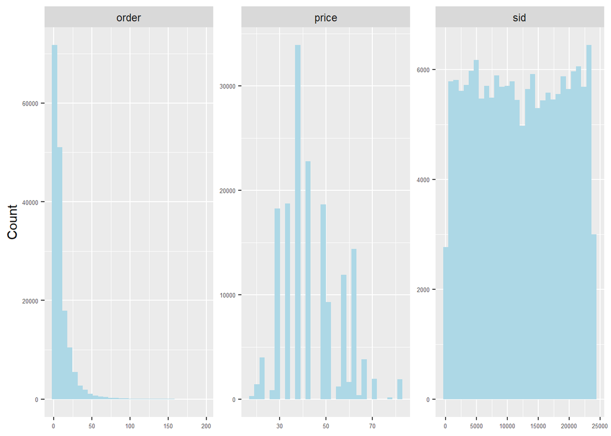

```r
clickstream %>% select(where(is.numeric)) %>%
  pivot_longer(everything(), names_to = "variable", values_to = "value") %>%
  ggplot(aes(x = value)) +
  geom_histogram(bins = 30, fill = "lightblue") +
  facet_wrap(~ variable, scales = "free") +
  labs(x = NULL, y = "Count") +
  theme(axis.text.x = element_text(size = 5),
        axis.text.y = element_text(size = 5))
```

# Multivariate Analysis

[figure not shown]

```r
par(mfrow = c(1, 2))

barplot(
  table(as.integer(format(clickstream$date, "%m"))),
  main = "Frequency of price_2",
  xlab = "Category",
  ylab = "Count",
  col = "lightblue"
)

barplot(
  table(clickstream$country),
  main = "Frequency of price_2",
  xlab = "IP",
  ylab = "Count",
  col = "lightblue"
)
```

```r
as.data.frame(table(clickstream$country)) %>% arrange(desc(Freq)) %>% head(5)
```

```
##   Var1   Freq
## 1   29 133963
## 2    9  18003
## 3   24   4091
## 4   46   2522
## 5   44   1385
```